# The Circle Maneuver

## General comments:

There is an extensive discussion of the circle maneuver in the NCAR Technical Note on Uncertainty in Wind Measurements, in Section 7.1. Some of that discussion is repeated here, but the treatment is condensed from that source.

The circle maneuver is flown by maintaining a constant roll angle so that the flight track drifts with the wind. The maneuver should include both left-turn and right-turn circles, preferably turning 720<sup>∘</sup>in each direction, although turns that are each a little more than 360<sup>∘</sup> can also be used. A one-minute straight leg before and after the maneuver is desirable. Conditions with constant horizontal and near-zero vertical wind are needed. The preferred orientation is for the straight legs to be along or against the wind direction, but this is not required. The circles are best flown under control of the flight management system, with heading bug turned so as to keep ahead of the heading, because this produces a constant-rate turn (with a rate that may change with altitude). The turn rate is often <3 min for a 360<sup>∘</sup> turn at intermediate flight altitudes for the aircraft but takes longer at higher altitudes in order to avoid loss of altitude. The time for a 360<sup>∘</sup> turn (**T** ) at airspeed (**V** ) and roll angle **(ϕ**) is given by **T = 2πV∕(g** **tanϕ**. For the particular C-130 example used here, the bank angle was about 26.7<sup>∘</sup>and **T = 159** s for flight at 125 m/s, at an altitude of about 12,500 ft.

The circle maneuver provides several checks on the measurements of wind:

The drift of the pattern provides a measurement of the wind that is dependent only on positions from the GPS receiver and is independent of the INS, except for confirming that the roll remains steady. The result should be within about 0.5 m/s of the mean wind measured during the circle maneuver and during the straight legs.

From the assumption that the horizontal wind should remain steady, sinusoidal variations in the measured wind can be used to estimate the error in airspeed and the error in the combination of the measurements of heading and sideslip.

An erroneous time shift between the heading variable and the INS-measured groundspeed components can be detected because it will appear as a heading error that differs in right-turn vs left-turn circles.

If there is no mean updraft around the circle, the error in sideslip angle can be separated from the error in heading because they enter the wind equations differently when the roll angle of the aircraft is significant. This appears to be the only maneuver that is sensitive to this offset.

## Estimating offsets in measured airspeed and flight direction

The key equations, with variables **v** and **λ** representing the true wind speed and direction, **v**<sub>**m**</sub> the measured wind speed with error **δv**<sub>**m**</sub>, **V** and **δV** the true airspeed and (assumed constant) error in true airspeed, **ψ** and **δψ** the heading and error in heading, **ϕ** the roll angle, and **β** and **δβ** the sideslip angle and error in sideslip, are:

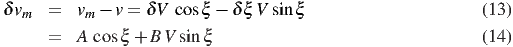

where **ξ** is the angle between the flight direction relative to the air and the wind direction, defined as **ξ = ψ +β** **cosϕ -λ** and having error **δξ** ≈ **δψ +δβ** **cosϕ**. If it is assumed that the wind speed remains steady, best-fit values for the three parameters {**v, A, B**} can be found by minimizing the error measure **χ**<sup>**2**</sup> **=** ∑**(δv**<sub>**m**</sub>**)**<sup>**2**</sup>. This leads to the estimated errors **δV = A** and **δξ = -B,** or needed corrections to **V** and **ξ** of opposite sign (**-A, B**). These equations conform to the expectation that comparing wind measured while flying upwind to that measured while flying downwind results in a difference that is twice the error in true airspeed, while comparing wind measured while flying crosswind with wind from starboard to that measured while flying with wind from port results in a difference that is twice the heading error (corrected for sideslip error) multiplied by the true airspeed. However, fitting to the full circle makes it possible to use all the measurements to estimate these errors. The signs as listed have been verified by refitting after applying these corrections to ensure that the adjustments remove the sinusoidal fluctuations.

Before using the results from these fits, two corrections need to be considered:

A time shift between the measurements of heading and INS-provided ground-speed components will appear as a false error in **ξ** . This can be detected by comparing the right-turn circle(s) to the left-turn circle(s), because an erroneous time shift will produce errors of opposite sign for the two turn directions. It is important to correct for the time shift before fitting. A good estimate of the time shift can be obtained by comparing the fitted values of **B** (**B**<sub>**L**</sub> for left-turn circles and **B**<sub>**R**</sub> for right-turn circles). If the mean turn rate during the circle-track portions of the circle maneuver is **R**, the time shift needed can be estimated from

[output not shown]

This time shift should be applied to the heading (THDG) before (14) is used to find the errors in **V** and **ξ** . Other time shifts (e.g., INS vs radome measurements) do not influence the deduced errors because the relative wind stays approximately constant during the turns. Only its transformation to Earth-based coordinates, dependent on THDG, affects the fit.

The turns are of long enough duration to show effects from the lever-arm correction arising from the displacement between the GPS antenna and the INS. Normally, the complementary filter used to calculate horizontal wind eliminates most effects from this lever-arm correction, but long-duration turns are an exception because the same correction is needed for several minutes. The straightforward solution is to recalculate the horizontal wind without the complementary filter and with inclusion of the correction term for displacement between the INS and the GPS antenna. This can lead to a change in wind speed arising from elimination of the update to the GPS-provided measurements of ground-speed components, so the fit-result **v** should not be considered a reliable estimate of the true wind speed. However, the complementary-filter update normally makes a slowly varying correction, varying with a period comparable to the period of the Schuler oscillation, so for the purposes of the circle-maneuver analysis this shift in mean wind speed does not affect analysis of the maneuver.

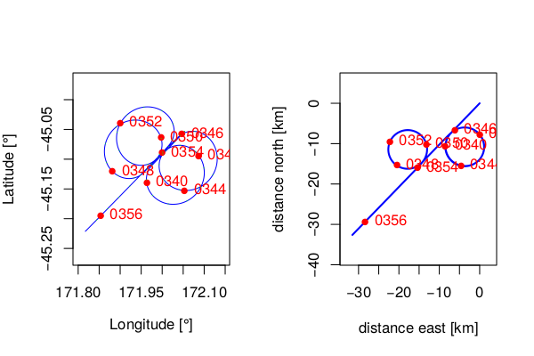

Figure 7: Portion of the flight track from DEEPWAVE rf15, 3:38:30–3:56:30 UTC, showing the circle maneuver flown at that time. The left panel shows the geographic position of the track, and the right panel shows the same track in a reference frame drifting with the wind.

A problem with this approach is that the true wind direction **λ** is needed to provide the reference direction for **ξ** , yet an error in wind measurement will introduce an error in this reference direction. The circle pattern largely corrects for this by including equal weighting of errors from all directions of flight, but it still may be better to determine the wind direction solely from the drift of the pattern as measured by GPS. That largely removes the wind-measuring system from the process and so should provide a better reference direction for use in (14. This can be done by fitting the dead-reckoning flight track adjusted by the wind vector to the ground-speed track, or equivalently the dead-reckoning flight speed adjusted by the wind vector to the measured ground speed from GPS. This fit can use one fit parameter that represents an offset in heading, so that such an error will be corrected in the fit and should not affect the deduced wind direction. Usually this is not necessary and the mean wind direction **λ** can be used, or alternately **λ** can be an additional parameter in the fit.

The procedure for finding the wind solely from the drift of the circle pattern is as follows. The horizontal components of the ground-relative motion of the aircraft, as measured from the aircraft, are these:

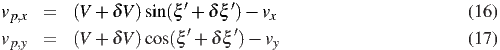

where **v**<sub>**p,x**</sub> and **v**<sub>**p,y**</sub> are the east and north components of the aircraft motion, **v**<sub>**x**</sub> and **v**<sub>**y**</sub> are the corresponding components of the wind, **V** is the true airspeed with possible error **δV** , **ξ** represents the direction of flight and so, for **β**=sideslip, **α =**angle-of-attack, and **ϕ =**roll, is **ξ**<sup>′</sup> **= ψ +β** **cosϕ -α** **sinϕ**. (The angle of attack enters here, while it did not in (14), because there the angle of attack and sideslip have already entered the calculation of wind so only the error in sideslip is relevant, while any error in angle of attack is neglected. That is the reason that the variable here has a prime accent.) For fit parameters **v**<sub>**x**</sub>, **v**<sub>**y**</sub>, **δV** , and **δξ** , best-fit values can be found by minimizing the following error measure:

[output not shown]

where **v**<sub>**g,x**</sub> and **v**<sub>**g,y**</sub> are the ground-speed components measured by GPS. The result is that the estimated wind direction is 222.8 with magnitude 17.7 m/s. This direction will then be used for the direction **λ** entering the relative angle **ξ** in (14). For comparison, the mean wind determined from the measurements was 222.9 / 17.8, so these two approaches gave essentially the same wind vector.

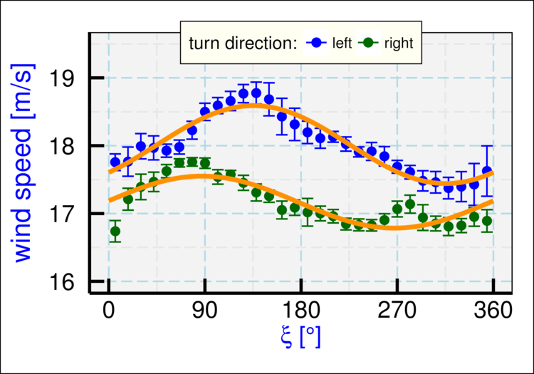

Figure 8: Measured wind speed from the left-turn and right-turn circles in the circle pattern shown in Fig. 7, as a function of **ξ** , the difference between the adjusted heading and the mean wind direction. Orange lines are the results of fitting (14) to the measurements.

Figure 8 shows the measured wind speed as a function of the angle between the heading adjusted by sideslip and the mean wind direction determined by the preceding fit. There is a clear sinusoidal variation in both components, so it is useful to fit (14) to these measurements to determine the magnitude of the corrections. The results for the left-turn circles and the right-turn circles are slightly different, as shown in the following table:

| turn direction | **δV** [m/s] | **δξ** [<sup>∘</sup>] | wind speed **σ**<sub>**W**</sub>[m/s] | **σ**<sub>**W**</sub>corrected [m/s] |
| --- | --- | --- | --- | --- |
| left | 0.41 | 0.15 | 0.46 | 0.21 |
| right | -0.02 | 0.14 | 0.34 | 0.2 |
| averaged | 0.2 | 0.15 |  |  |

When the deduced corrections to airspeed and adjusted-heading (**ξ** ) are applied, the last column shows that the standard deviation in wind speed is reduced significantly, to a value comparable to that in the straight leg approaching the turns (0.24 m/s), so the tabulated adjustments successfully remove the errors in the measurement of wind speed. The tabulated errors are comparable to those expected for airspeed and heading, as determined in the NCAR Technical Note “Uncertainty in Wind Measurements ...”, so this is good verification that the wind system is performing as expected.

While the error in **ξ** is smaller than the INS specification for expected error in heading but larger than other estimates obtained, e.g., in the cited NCAR Technical Note or the Technical Note on development of a Kalman filter. Both of those lead lead to an expectation that this error is smaller in magnitude than about 0.05<sup>∘</sup>. However, the indicated error in direction is **δξ = δψ +δβ** **cosϕ**, and it is not possible to separate the error in heading from the error in sideslip because **cosϕ** is constant throughout the left-turn and right-turn circles. Therefore, another approach to checking the sideslip angle is needed, as discussed in the next section.

## Estimating the separate errors in heading and sideslip

For level flight with zero vertical wind, the transformation equations from [RAF Bulletin 23](https://www.eol.ucar.edu/raf/Bulletins/bulletin23.html) indicate that **-sinθ +sinϕ** **tanβ +cosϕ** **tanα = 0**, where **θ** is the pitch, **ϕ** the roll, **α** the angle of attack, and **β** the sideslip angle. Pitch and angle of attack can be assumed accurate because the former is checked, as part of the recalculation procedure, via determining the correction for Schuler oscillation and the latter is calibrated to low uncertainty via speed runs. Thus this equation can be used to deduce the offset in the measurement of sideslip, while other maneuvers such as yaw maneuvers or reverse-heading maneuvers cannot separate a sideslip offset from a heading offset. For small angles such that **tanβ** ≈ **β**, **tanα** ≈ **α** and **sinθ** ≈ **θ**, **β** **sinϕ** ≈ **θ**-**α** **cosϕ**. With angle of attack and pitch remaining about the same in the left-turn and right-turn circles, but roll changing sign, it is expected that **β** will also change sign symmetrically from right-turn to left-turn circles. This can be checked via plots of sideslip vs time, as shown in the wind-uncertainty technical note, but instead the sideslip will be checked here by plotting the estimated error in **β**<sub>**m**</sub> required for **β** to satisfy the preceding equation, rewritten as

[output not shown]

where **β**<sub>**m**</sub> is the measured sideslip and **δβ** is the error in sideslip (or the negative of the needed correction). The calibration coefficients for SSRD used to produce this data file were {0.09, 21.723}, For measurements from the circle maneuvers, the mean value of the estimated error **δβ** from (19) was 0.049<sup>∘</sup>**±**0.003<sup>∘</sup>, so this indicates that the constant sensitivity coefficient for SSRD shoud have this error *subtracted* to give a new value of 0.041. The measurements in the table above suggest that the error in **ξ** is 0.15<sup>∘</sup>, so if the error in sideslip is 0.049 the error in heading is indicated to be **δψ = δξ -δβ** **cosϕ** ≈0.10<sup>∘</sup>.

## Summary

This circle maneuver leads to estimated errors in airspeed, heading, and sideslip (TASX, THDG, SSRD} that are {0.2 m/s, 0.10<sup>∘</sup>, 0.05<sup>∘</sup>}.

## Using the QA circle-analysis tool

Circle maneuvers can be analysed with the QA tool as follows:

From the home page, select “Past Projects” → “Maneuvers” → “Circle”.

Select a project from the “Project” menu near the top left corner. If there are any circle maneuvers for the project in the database, they will be displayed as a set of radio buttons below the “select circle maneuver” heading. If there are none, only the word “none” will be displayed. Projects with good circle maneuvers include ARISTO2017, HCRTEST, and DEEPWAVE as well as some other projects.

Click on one of the radio buttons, and select “plot track” from the “plot drop-down menu. This will show the flight track in a drifting reference frame, so the track should be circular and usually will include left-turn and right-turn circles. You can adjust the “set interval” slider to fine tune the time covered by the plot. It should include complete circles and some straight legs.

Next select the “WS fit” option under the “plot” menu. This shows the wind-speed measurements as a function of ξ, the angle between the flight direction and the wind direction. The plot should be similar to Fig. 8 above. The left-turn and right-turn circles are plotted separately and fitted to sinusoidal-varying functions as in (14) above, to determine estimated errors in airspeed and heading. Before this plot is generated, the heading measurement is shifted in time as indicated by (15) above to minimize the difference between the results from the left-turn circles and the right-turn circles. The title of the plot lists the estimated error in airspeed, and the subtitle lists the estimated error in angle as well as the time shift applied to the heading. The caption at the bottom right of the figure includes the standard deviation in measured wind speed before correction and after correction, and it also lists the standard deviation in airspeed for comparison .

Next select the “SSRD offset” item in the “plot” menu. This will generate a histogram of estimated error in sideslip, calculated from (19). The histogram will be broad because any individual measurement has large random error, but the mean of the many measurements in the circle maneuver has low standard deviation as listed in the plot title. Because the angle error found in step 4 (called the “modified HDG” in the subtitle) combines the errors in heading and sideslip, as indicated by the formula in the text following (14), this step is needed to separate these two contributions. Also listed in the plot title are the first sensitivity coefficient for SSRD, the adjusted coefficient that this analysis indicates should be used, and the separate heading error.

—- END —-